# Univariate: GRAVIER

Jose Tamez

2023-02-02

# 1 GRAVIER Univariate

### 1.0.1 Loading the libraries

```r
library("FRESA.CAD")
library(readxl)
op <- par(no.readonly = TRUE)
pander::panderOptions('digits', 3)
pander::panderOptions('table.split.table', 400)
pander::panderOptions('keep.trailing.zeros',TRUE)
```

## 1.1 The Data

```r
data('gravier', package = 'datamicroarray')
table(gravier$y)
```

```
#>
#> good poor
#>  111   57
```

```r
gravierset <- as.data.frame(cbind(class=1*(gravier$y=="poor"),gravier$x))

gravier <- NULL
```

#### 1.1.0.1 Standarize the names for the reporting

```r
dataframe <- gravierset
outcome <- "class"
```

```r
pander::pander(c(rows=nrow(dataframe),col=ncol(dataframe)-1))
```

| rows | col |
| --- | --- |
| 168 | 2905 |

```r
pander::pander(table(dataframe[,outcome]))
```

| 0 | 1 |
| --- | --- |
| 111 | 57 |

```r
varlist <- colnames(dataframe)
varlist <- varlist[varlist != outcome]
varlist <- as.data.frame(cbind(name=varlist,desc=varlist))
```

## 1.2 Univariate

```r
univariate_columns <- c("caseMean","caseStd","controlMean","controlStd","cohortKSP","ROCAUC","WilcoxRes.p","FRes.p")
univar <- uniRankVar(varlist,
               paste(outcome,"~1"),
               outcome,
               dataframe,
               categorizationType = "Raw",
               type = "LOGIT",
               rankingTest = "AUC",
                cateGroups = c(0.1, 0.9),
                raw.dataFrame = NULL,
                description = ".",
                uniType = "Binary")
```

100 : g1A07 200 : g3H03 300 : g1E07 400 : g4F03 500 : g4C05  
600 : g1int292 700 : g1int356 800 : g7A03 900 : g4D11 1000 : g1int577  
1100 : g1CNS420 1200 : g7G07 1300 : g1int785 1400 : g1CNS59 1500 : g1CNS178  
1600 : g1int949 1700 : g1int1028 1800 : g1int1089 1900 : g11D05 2000 : g1int1222  
2100 : g1int1298 2200 : g1int1376 2300 : g1int1449 2400 : g10E08 2500 : g1CNS90  
2600 : g7F11 2700 : g1int1693 2800 : g1CNS93 2900 : g1int1800

```r
pander::pander(univar$orderframe[1:20,univariate_columns])
```

|  | caseMean | caseStd | controlMean | controlStd | cohortKSP | ROCAUC | WilcoxRes.p | FRes.p |
| --- | --- | --- | --- | --- | --- | --- | --- | --- |
| **g1CNS507** | -0.2495 | 0.222 | -0.02479 | 0.1946 | 0.107455 | 0.796 | 5.15e-11 | 8.71e-12 |
| **g1CNS105** | 0.2542 | 0.270 | 0.05332 | 0.1720 | 0.015509 | 0.749 | 1.15e-08 | 1.45e-08 |
| **g1CNS382** | -0.1710 | 0.173 | -0.03538 | 0.1449 | 0.155510 | 0.745 | 1.16e-08 | 3.57e-08 |
| **g1int804** | -0.2497 | 0.220 | -0.07745 | 0.2051 | 0.091566 | 0.743 | 4.95e-08 | 1.74e-07 |
| **g1CNS91** | 0.3099 | 0.294 | 0.09938 | 0.1383 | 0.000815 | 0.742 | 6.66e-09 | 3.71e-10 |
| **g1CNS26** | -0.1447 | 0.169 | -0.01013 | 0.1253 | 0.339417 | 0.738 | 2.18e-08 | 1.57e-09 |
| **g1int340** | -0.1571 | 0.183 | -0.01691 | 0.1391 | 0.000714 | 0.737 | 2.58e-08 | 6.12e-08 |
| **g1CNS70** | 0.1523 | 0.177 | 0.03519 | 0.1152 | 0.000282 | 0.731 | 9.81e-09 | 1.92e-07 |
| **g1CNS158** | 0.2598 | 0.251 | 0.10067 | 0.1674 | 0.000124 | 0.731 | 2.97e-07 | 1.18e-06 |
| **g1CNS28** | 0.2184 | 0.218 | 0.07444 | 0.1432 | 0.002421 | 0.726 | 5.35e-08 | 3.86e-07 |
| **g1int845** | 0.1812 | 0.215 | 0.03780 | 0.1268 | 0.006944 | 0.725 | 2.82e-08 | 1.60e-08 |
| **g8D02** | -0.0865 | 0.177 | 0.02740 | 0.1370 | 0.000619 | 0.725 | 6.37e-08 | 2.49e-06 |
| **g1CNS159** | 0.1923 | 0.249 | 0.04601 | 0.1735 | 0.000203 | 0.723 | 3.05e-07 | 9.45e-06 |
| **g1CNS20** | 0.2084 | 0.251 | 0.03454 | 0.1504 | 0.003583 | 0.723 | 1.14e-07 | 4.89e-08 |
| **g1int810** | -0.2610 | 0.226 | -0.10390 | 0.2086 | 0.045293 | 0.722 | 1.89e-07 | 1.06e-06 |
| **g1CNS493** | -0.1948 | 0.186 | -0.06224 | 0.1573 | 0.213567 | 0.721 | 3.50e-07 | 6.87e-07 |
| **g1int1671** | 0.1263 | 0.140 | 0.03969 | 0.1218 | 0.008533 | 0.719 | 2.21e-07 | 1.91e-05 |
| **g5G04** | 0.3035 | 0.250 | 0.13352 | 0.1959 | 0.025867 | 0.717 | 1.56e-06 | 1.95e-06 |
| **g9E01** | 0.0911 | 0.163 | -0.00465 | 0.0984 | 0.000390 | 0.717 | 2.59e-07 | 7.06e-07 |
| **g1int812** | -0.1926 | 0.214 | -0.04622 | 0.1755 | 0.380814 | 0.716 | 1.27e-06 | 3.56e-07 |

```r
topfiveOrg <- rownames(univar$orderframe[1:5,])
```

### 1.2.1 ROC plot of top feature

```r
topvar <- univar$orderframe$Name[1]
cmod <- glm(formula(paste(outcome,"~",topvar)),dataframe,family="binomial");
pmod <- predict(cmod,dataframe)


perd <- cbind(dataframe[,outcome],pmod)
prSurvTest <- predictionStats_binary(perd,topvar)
```

g1CNS507

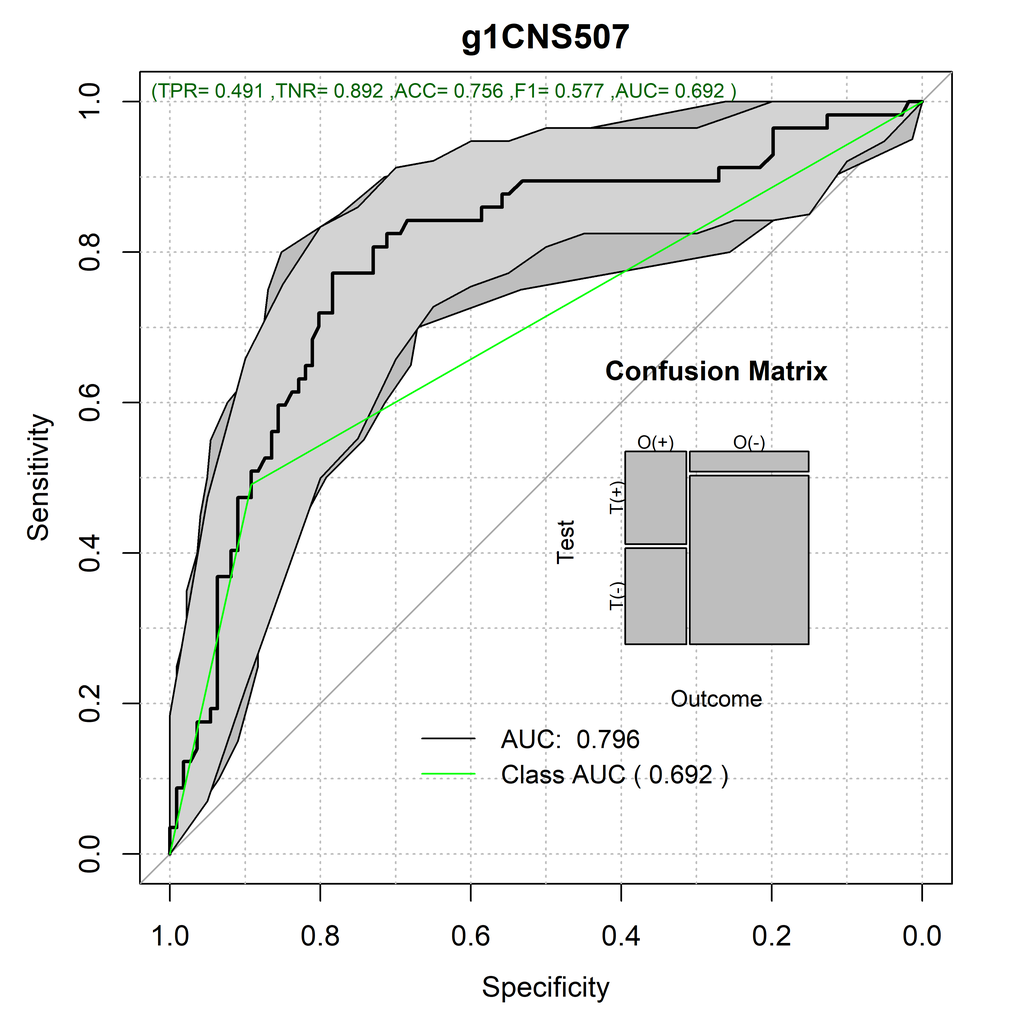

```r
pander::pander(prSurvTest$CM.analysis$tab)
```

|  | Outcome + | Outcome - | Total |
| --- | --- | --- | --- |
| **Test +** | 28 | 12 | 40 |
| **Test -** | 29 | 99 | 128 |
| **Total** | 57 | 111 | 168 |

```r
pander::pander(prSurvTest$aucs)
```

| est | lower | upper |
| --- | --- | --- |
| 0.796 | 0.721 | 0.871 |

## 1.3 Decorrelation Analysis

```r
DEdataframe <- IDeA(dataframe,thr=0.80,verbose = TRUE)
```

Included: 2905 , Uni p: 0.005225049 , Uncorrelated Base: 2140 , Outcome-Driven Size: 0 , Base Size: 2140

1 <R=0.983,w= 1,N= 14>, Top: 5( 2 )1 : 5 : 0.966,<|>Tot Used: 13 , Added: 8 , Zero Std: 0 , Max Cor: 0.959

2 <R=0.959,w= 1,N= 14>, Top: 3( 2 )1 : 3 : 0.955,<|>Tot Used: 18 , Added: 4 , Zero Std: 0 , Max Cor: 0.953

3 <R=0.953,w= 1,N= 14>, Top: 2( 1 )1 : 2 : 0.951,<|>Tot Used: 21 , Added: 2 , Zero Std: 0 , Max Cor: 0.950

4 <R=0.950,w= 2,N= 52>, Top: 22( 2 )1 : 22 : 0.925,<|>Tot Used: 68 , Added: 29 , Zero Std: 0 , Max Cor: 0.924

5 <R=0.924,w= 2,N= 52>, Top: 17( 1 )1 : 17 : 0.912,<|>Tot Used: 95 , Added: 18 , Zero Std: 0 , Max Cor: 0.914

6 <R=0.914,w= 2,N= 52>, Top: 18( 1 )1 : 18 : 0.907,<|>Tot Used: 123 , Added: 18 , Zero Std: 0 , Max Cor: 0.907

7 <R=0.907,w= 2,N= 52>, Top: 4( 1 )1 : 4 : 0.903,<|>Tot Used: 130 , Added: 4 , Zero Std: 0 , Max Cor: 0.903

8 <R=0.903,w= 3,N= 368>, Top: 127( 2 ).=2 : 127 : 0.877,<|>Tot Used: 417 , Added: 196 , Zero Std: 0 , Max Cor: 0.894

9 <R=0.894,w= 3,N= 368>, Top: 33( 2 )1 : 33 : 0.847,<|>Tot Used: 470 , Added: 36 , Zero Std: 0 , Max Cor: 0.867

10 <R=0.867,w= 4,N= 580>, Top: 201( 3 ).=( 1 )2 : 201 : 0.834,<|>Tot Used: 865 , Added: 295 , Zero Std: 0 , Max Cor: 0.823

11 <R=0.823,w= 4,N= 580>, Top: 8( 4 )1 : 8 : 0.800,<|>Tot Used: 886 , Added: 15 , Zero Std: 0 , Max Cor: 0.800

12 <R=0.000,w= 5,N= 0>

[ 12 ], 0.797965 Decor Dimension: 886 . Cor to Base: 535 , ABase: 219 , Outcome Base: 0

```r
demat <- attr(DEdataframe,"UPSTM")

pander::pander(c(Cols=ncol(demat),Rows=nrow(demat)))
```

| Cols | Rows |
| --- | --- |
| 886 | 886 |

```r
totFe <- ncol(DEdataframe)-1
totBa <- sum(str_detect(colnames(DEdataframe),"Ba_"))
totDe <- sum(str_detect(colnames(DEdataframe),"La_"))
toUnmat <- sum(apply(demat!=0,2,sum)==1)
unaltered <- totFe - ncol(demat) + toUnmat
pander::pander(c(Features=totFe,totBa=totBa,totDe=totDe,unaltered=totFe-totBa-totDe,totuna=unaltered))
```

| Features | totBa | totDe | unaltered | totuna |
| --- | --- | --- | --- | --- |
| 2905 | 0 | 624 | 2281 | 2281 |

```r
pander::pander(c(Decorrleated_Fraction=sum(str_detect(colnames(DEdataframe),"La_"))/(ncol(DEdataframe)-1)))
```

| Decorrleated_Fraction |
| --- |
| 0.215 |

```r
pander::pander(c(Base_Fraction=sum(str_detect(colnames(DEdataframe),"Ba_"))/(ncol(DEdataframe)-1)))
```

| Base_Fraction |
| --- |
| 0 |

```r
pander::pander(c(Unaltered_Fraction=unaltered/totFe))
```

| Unaltered_Fraction |
| --- |
| 0.785 |

```r
pander::pander(c(sparcity=(totFe-ncol(demat)+sum(abs(demat)!=0))/totFe/totFe))
```

| sparcity |
| --- |
| 0.000418 |

```r
varlistDe <-  colnames(demat)[apply(demat!=0,2,sum)>1];
varlistDe <- as.data.frame(cbind(name=varlistDe,desc=varlistDe))
```

### 1.3.1 The heat maps.

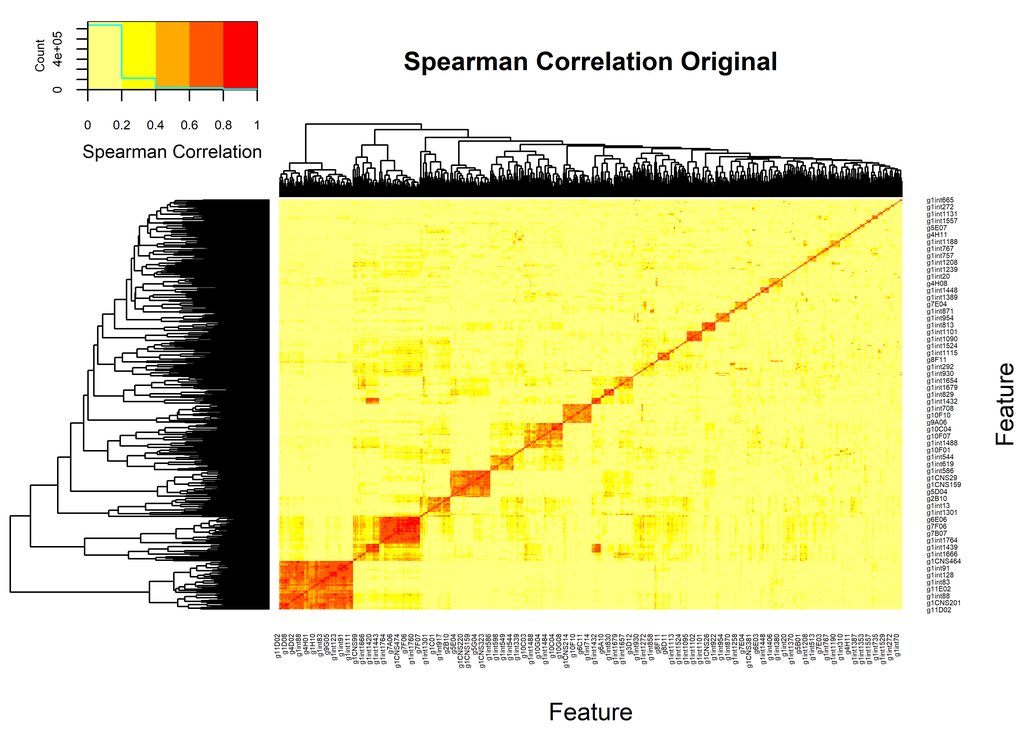

```r
par(cex=0.6,cex.main=0.85,cex.axis=0.7)
cormat <- cor(dataframe[,rownames(demat)],method="spearman")
cormat[is.na(cormat)] <- 0
gplots::heatmap.2(abs(cormat),
                  trace = "none",
#                  scale = "row",
                  mar = c(5,5),
                  col=rev(heat.colors(5)),
                  main = "Spearman Correlation Original",
                  cexRow = 0.35,
                  cexCol = 0.35,
                  key.title=NA,
                  key.xlab="Spearman Correlation",
                  xlab="Feature", ylab="Feature")
```

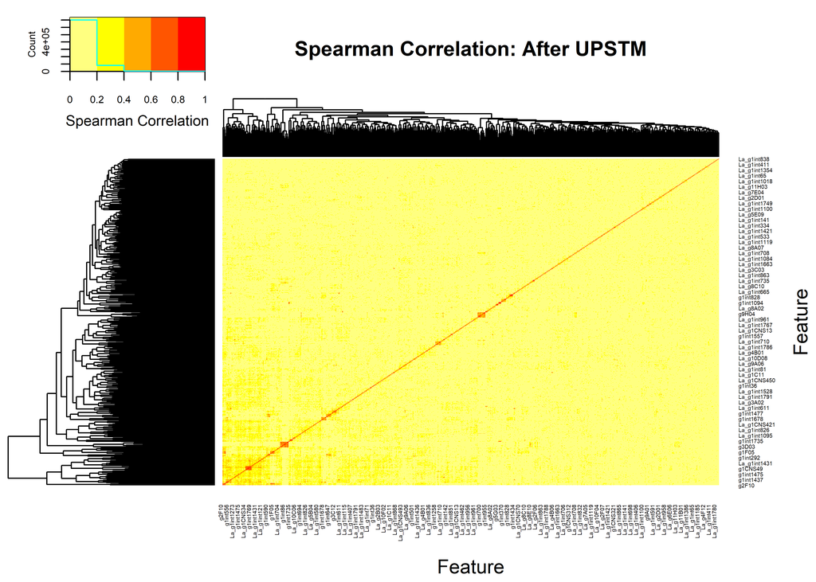

```r
cormat <- cor(DEdataframe[,colnames(demat)],method="spearman")
cormat[is.na(cormat)] <- 0
gplots::heatmap.2(abs(cormat),
                  trace = "none",
#                  scale = "none",
                  mar = c(5,5),
                  col=rev(heat.colors(5)),
                  main = "Spearman Correlation: After UPSTM",
                  cexRow = 0.35,
                  cexCol = 0.35,
                  key.title=NA,
                  key.xlab="Spearman Correlation",
                  xlab="Feature", ylab="Feature")
```

```r
par(op)
```

## 1.4 Univariate Decorrelated

```r
univarDe <- uniRankVar(varlistDe,
              paste(outcome,"~1"),
                outcome,
              DEdataframe,
                categorizationType = "Raw",
                type = "LOGIT",
                rankingTest = "AUC",
                cateGroups = c(0.1, 0.9),
                raw.dataFrame = NULL,
                description = ".",
                uniType = "Binary")
```

100 : La_g1int115 200 : La_g1int669 300 : La_g1CNS91 400 : La_g5B09 500 : La_g10B08  
600 : La_g1CNS188

```r
pander::pander(univarDe$orderframe[1:20,univariate_columns])
```

|  | caseMean | caseStd | controlMean | controlStd | cohortKSP | ROCAUC | WilcoxRes.p | FRes.p |
| --- | --- | --- | --- | --- | --- | --- | --- | --- |
| **La_g2D01** | -0.076108 | 0.0794 | -0.02697 | 0.0604 | 4.26e-01 | 0.704 | 2.92e-06 | 2.07e-06 |
| **La_g1int829** | 0.027457 | 0.0662 | -0.01816 | 0.0654 | 8.03e-01 | 0.700 | 8.82e-06 | 7.57e-06 |
| **La_g1int110** | 0.125765 | 0.0776 | 0.07341 | 0.0797 | 2.56e-01 | 0.690 | 4.62e-05 | 8.94e-06 |
| **La_g1int817** | -0.009783 | 0.0819 | 0.02947 | 0.0841 | 1.58e-01 | 0.685 | 6.95e-05 | 6.20e-04 |
| **La_g1int1102** | -0.075044 | 0.0969 | -0.02083 | 0.0888 | 7.36e-01 | 0.674 | 7.18e-05 | 8.62e-05 |
| **La_g2G09** | 0.002107 | 0.0650 | 0.03798 | 0.0699 | 7.05e-02 | 0.668 | 1.15e-04 | 1.02e-03 |
| **La_g6H03** | 0.000405 | 0.1480 | -0.04587 | 0.0647 | 8.61e-05 | 0.667 | 7.14e-05 | 7.85e-04 |
| **La_g1A11** | 0.023381 | 0.0650 | -0.01444 | 0.0655 | 1.77e-01 | 0.666 | 2.42e-04 | 3.14e-04 |
| **La_g1int830** | 0.014786 | 0.0844 | -0.02510 | 0.0695 | 4.83e-01 | 0.661 | 2.52e-04 | 4.07e-04 |
| **La_g1int380** | 0.038087 | 0.0865 | -0.00424 | 0.0529 | 2.71e-01 | 0.653 | 1.25e-04 | 1.81e-05 |
| **La_g1CNS200** | 0.021917 | 0.0796 | 0.06445 | 0.0939 | 7.25e-01 | 0.653 | 3.49e-04 | 1.71e-03 |
| **La_g7F06** | -0.070086 | 0.0892 | -0.02939 | 0.0770 | 7.70e-01 | 0.653 | 4.76e-04 | 6.73e-04 |
| **La_g1int326** | -0.061350 | 0.0735 | -0.02468 | 0.0578 | 3.43e-01 | 0.651 | 1.64e-04 | 1.68e-04 |
| **La_g8G06** | -0.046566 | 0.1061 | 0.00428 | 0.0907 | 1.75e-02 | 0.648 | 1.98e-04 | 4.09e-04 |
| **La_g3F01** | -0.025040 | 0.0810 | 0.00293 | 0.0781 | 4.19e-02 | 0.647 | 8.14e-04 | 1.30e-02 |
| **La_g1int1430** | 0.097099 | 0.0848 | 0.05421 | 0.0807 | 7.82e-01 | 0.646 | 1.07e-03 | 6.13e-04 |
| **La_g1int609** | -0.022645 | 0.0764 | 0.01828 | 0.0698 | 8.27e-01 | 0.645 | 3.77e-04 | 2.22e-04 |
| **La_g1int1612** | 0.019942 | 0.0676 | -0.01092 | 0.0850 | 4.14e-04 | 0.644 | 4.27e-04 | 4.83e-03 |
| **La_g1int748** | 0.031399 | 0.0762 | 0.00524 | 0.0573 | 2.45e-01 | 0.638 | 3.05e-03 | 2.15e-03 |
| **La_g1CNS54** | 0.012230 | 0.1030 | 0.04614 | 0.0810 | 4.94e-02 | 0.638 | 6.02e-04 | 6.06e-03 |

### 1.4.1 ROC plot of top feature

```r
topvar <- univarDe$orderframe$Name[1]
cmod <- glm(formula(paste(outcome,"~",topvar)),DEdataframe,family="binomial");
pmod <- predict(cmod,DEdataframe)


perd <- cbind(DEdataframe[,outcome],pmod)
prSurvTest <- predictionStats_binary(perd,topvar)
```

La_g2D01

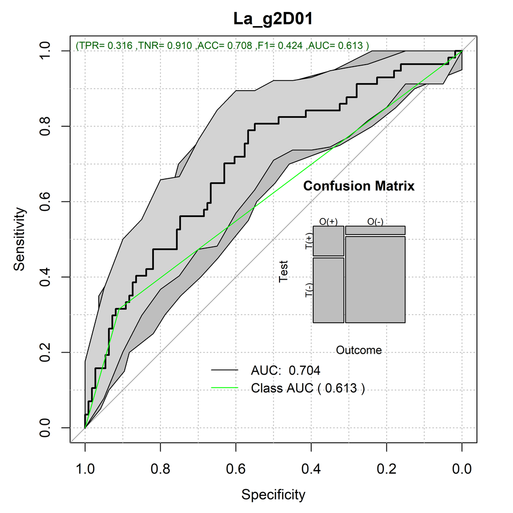

```r
pander::pander(prSurvTest$CM.analysis$tab)
```

|  | Outcome + | Outcome - | Total |
| --- | --- | --- | --- |
| **Test +** | 18 | 10 | 28 |
| **Test -** | 39 | 101 | 140 |
| **Total** | 57 | 111 | 168 |

```r
pander::pander(prSurvTest$aucs)
```

| est | lower | upper |
| --- | --- | --- |
| 0.704 | 0.62 | 0.788 |

### 1.4.2 Comparing Decorrelation vs Original

```r
pthr <- 0.20/(ncol(dataframe)-1)

topDecorNames <- rownames(univarDe$orderframe[univarDe$orderframe$FRes.p<pthr,])
topDecorNames <- unique(c(topDecorNames,rownames(univarDe$orderframe[1:5,])))

#topDecorNames <- rownames(univarDe$orderframe[univarDe$orderframe$FRes.p<1.0e-4,])
dc <- getLatentCoefficients(DEdataframe)
### 2a Get only the ones that in the top features
deNames_in_dc <- topDecorNames[topDecorNames %in% names(dc)]
selectedlist <- dc[deNames_in_dc]
theDeFormulas <- selectedlist

rawuniv <- univariate_Wilcoxon(dataframe,outcome,limit=-1)
deuniv <- univariate_Wilcoxon(DEdataframe,outcome,limit=-1)
matsize <- (ncol(dataframe)-1)^2
nocorrelated <- ncol(dataframe) - 1 - ncol(demat)
pander::pander(c(sparse_Fraction=(sum(demat != 0) + nocorrelated)/matsize))
```

| sparse_Fraction |
| --- |
| 0.000418 |

```r
pander::pander(c(raw=length(rawuniv),decor=length(deuniv)))
```

| raw | decor |
| --- | --- |
| 553 | 422 |

```r
pander::pander(c(Number_Latent=length(dc)))
```

| Number_Latent |
| --- |
| 624 |

```r
pander::pander(c(meanSize=mean(sapply(dc,length))))
```

| meanSize |
| --- |
| 2 |

## 1.5 CV ROC Analysis

```r
par(op)
par(mfrow=c(1,2),cex=0.9)
fraction <-0.80
repetitions <- 100

fcout <- round(fraction*nrow(dataframe)/15+1.0)
pander::pander(c(NumberofFeatures=fcout))
```

| NumberofFeatures |
| --- |
| 10 |

```r
cvRaw <- randomCV(dataframe,
                outcome,
                fittingFunction= filteredFit,
                classSamplingType = "Pro",
                trainFraction = fraction,
                repetitions = repetitions,
#                fitmethod=  glm,
                fitmethod=  KNN_method,
                filtermethod=mRMR.classic_FRESA,
                filtermethod.control=list(feature_count= fcout),
#                family="binomial"
)
```

……….10 Tested: 146 Avg. Selected: 10 Min Tests: 1 Max Tests: 6 Mean Tests: 2.39726 . MAD: 0.2901609

……….20 Tested: 166 Avg. Selected: 10 Min Tests: 1 Max Tests: 9 Mean Tests: 4.216867 . MAD: 0.282349

……….30 Tested: 168 Avg. Selected: 10 Min Tests: 1 Max Tests: 13 Mean Tests: 6.25 . MAD: 0.2777872

……….40 Tested: 168 Avg. Selected: 10 Min Tests: 4 Max Tests: 16 Mean Tests: 8.333333 . MAD: 0.2739448

……….50 Tested: 168 Avg. Selected: 10 Min Tests: 4 Max Tests: 18 Mean Tests: 10.41667 . MAD: 0.2737139

……….60 Tested: 168 Avg. Selected: 10 Min Tests: 6 Max Tests: 19 Mean Tests: 12.5 . MAD: 0.2753354

……….70 Tested: 168 Avg. Selected: 10 Min Tests: 7 Max Tests: 22 Mean Tests: 14.58333 . MAD: 0.2743079

……….80 Tested: 168 Avg. Selected: 10 Min Tests: 9 Max Tests: 27 Mean Tests: 16.66667 . MAD: 0.2752716

……….90 Tested: 168 Avg. Selected: 10 Min Tests: 10 Max Tests: 31 Mean Tests: 18.75 . MAD: 0.2751618

……….100 Tested: 168 Avg. Selected: 10 Min Tests: 12 Max Tests: 33 Mean Tests: 20.83333 . MAD: 0.2772912

```r
bpraw <- predictionStats_binary(cvRaw$medianTest,"RAW",cex=0.75)
```

RAW

```r
pander::pander(bpraw$CM.analysis$tab)
```

|  | Outcome + | Outcome - | Total |
| --- | --- | --- | --- |
| **Test +** | 25 | 7 | 32 |
| **Test -** | 32 | 104 | 136 |
| **Total** | 57 | 111 | 168 |

```r
pander::pander(bpraw$accc)
```

| est | lower | upper |
| --- | --- | --- |
| 0.768 | 0.697 | 0.829 |

```r
pander::pander(bpraw$aucs)
```

| est | lower | upper |
| --- | --- | --- |
| 0.84 | 0.78 | 0.901 |

```r
pander::pander(bpraw$berror)
```

| 50% | 2.5% | 97.5% |
| --- | --- | --- |
| 0.312 | 0.24 | 0.376 |

```r
cvDe <- randomCV(DEdataframe,
                outcome,
                fittingFunction= filteredFit,
                trainSampleSets= cvRaw$trainSamplesSets,
#                fitmethod=  glm,
                fitmethod=  KNN_method,
                filtermethod=mRMR.classic_FRESA,
                filtermethod.control=list(feature_count= fcout),
#                family="binomial"
)
```

……….10 Tested: 146 Avg. Selected: 10 Min Tests: 1 Max Tests: 6 Mean Tests: 2.39726 . MAD: 0.2861763

……….20 Tested: 166 Avg. Selected: 10 Min Tests: 1 Max Tests: 9 Mean Tests: 4.216867 . MAD: 0.2812649

……….30 Tested: 168 Avg. Selected: 10 Min Tests: 1 Max Tests: 13 Mean Tests: 6.25 . MAD: 0.2772516

……….40 Tested: 168 Avg. Selected: 10 Min Tests: 4 Max Tests: 16 Mean Tests: 8.333333 . MAD: 0.2716394

……….50 Tested: 168 Avg. Selected: 10 Min Tests: 4 Max Tests: 18 Mean Tests: 10.41667 . MAD: 0.2730844

……….60 Tested: 168 Avg. Selected: 10 Min Tests: 6 Max Tests: 19 Mean Tests: 12.5 . MAD: 0.2705711

……….70 Tested: 168 Avg. Selected: 10 Min Tests: 7 Max Tests: 22 Mean Tests: 14.58333 . MAD: 0.2728269

……….80 Tested: 168 Avg. Selected: 10 Min Tests: 9 Max Tests: 27 Mean Tests: 16.66667 . MAD: 0.271849

……….90 Tested: 168 Avg. Selected: 10 Min Tests: 10 Max Tests: 31 Mean Tests: 18.75 . MAD: 0.2727171

……….100 Tested: 168 Avg. Selected: 10 Min Tests: 12 Max Tests: 33 Mean Tests: 20.83333 . MAD: 0.2716707

```r
bpDecor <- predictionStats_binary(cvDe$medianTest,"Decorrelated",cex=0.75)
```

Decorrelated

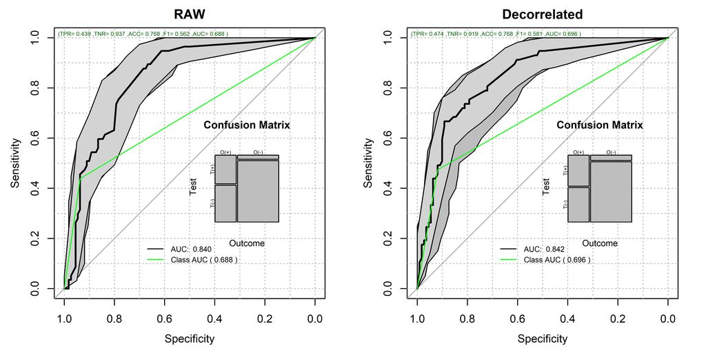

```r
par(op)

pander::pander(bpDecor$CM.analysis$tab)
```

|  | Outcome + | Outcome - | Total |
| --- | --- | --- | --- |
| **Test +** | 27 | 9 | 36 |
| **Test -** | 30 | 102 | 132 |
| **Total** | 57 | 111 | 168 |

```r
pander::pander(bpDecor$accc)
```

| est | lower | upper |
| --- | --- | --- |
| 0.768 | 0.697 | 0.829 |

```r
pander::pander(bpDecor$aucs)
```

| est | lower | upper |
| --- | --- | --- |
| 0.842 | 0.78 | 0.905 |

```r
pander::pander(bpDecor$berror)
```

| 50% | 2.5% | 97.5% |
| --- | --- | --- |
| 0.304 | 0.231 | 0.378 |

```r
### Here we compute the probability that the outcome-driven decorrelation ROC is superior to the RAW ROC.
pander::pander(roc.test(bpDecor$ROC.analysis$roc.predictor,bpraw$ROC.analysis$roc.predictor,alternative = "greater"))
```

DeLong’s test for two correlated ROC curves: `bpDecor$ROC.analysis$roc.predictor` and `bpraw$ROC.analysis$roc.predictor`

| Test statistic | P value | Alternative hypothesis | AUC of roc1 | AUC of roc2 |
| --- | --- | --- | --- | --- |
| 0.124 | 0.451 | greater | 0.842 | 0.84 |

## 1.6 Feature Frequency Plots

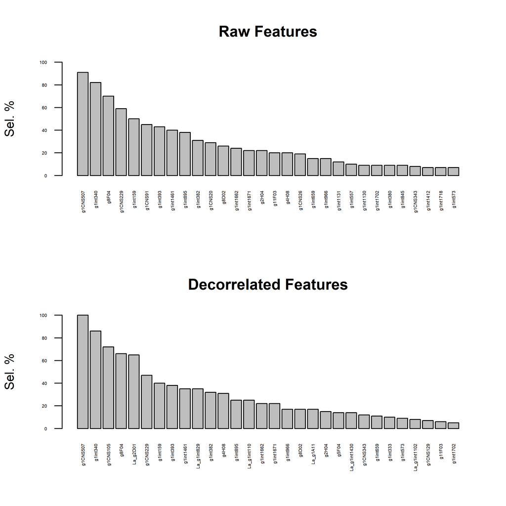

```r
par(mfrow=c(2,1),cex=0.9,cex.axis=0.8)

rawtopf <- cvRaw$featureFrequency/repetitions
crawtopf <- rawtopf

if (length(rawtopf) > 30)
{
  rawtopf <- rawtopf[1:30]
}
barplot(100*rawtopf,las=2,main="Raw Features",ylim=c(0,100.0),cex.names = 0.35,cex.axis = 0.35,ylab="Sel. %")

detopf <- cvDe$featureFrequency/repetitions
cdetopf <- detopf
names(cdetopf) <- str_remove_all(names(cdetopf),"Ba_")
names(cdetopf) <- str_remove_all(names(cdetopf),"La_")
if (length(detopf) > 30)
{
  detopf <- detopf[1:30]
}

barplot(100*detopf,las=2,main="Decorrelated Features",ylim=c(0,100.0),cex.names = 0.35,cex.axis = 0.35,ylab="Sel. %")
```

```r
par(op)
```

### 1.6.1 Final Table

```r
unlistdecorr <- selectedlist
names(unlistdecorr) <- NULL
unlistdecorr <- unique(names(unlist(unlistdecorr)))

finalTableDe <- univarDe$orderframe[deNames_in_dc,univariate_columns]

finalTableOr <- univar$orderframe[unique(c(topfiveOrg,unlistdecorr,names(crawtopf)[1:2],names(cdetopf)[1:2])),univariate_columns]

finalTable <- rbind(finalTableOr,finalTableDe)

deFromula <- character(length(theDeFormulas))
names(deFromula) <- names(theDeFormulas)

for (dx in names(deFromula))
{
  coef <- theDeFormulas[[dx]]
  cname <- names(theDeFormulas[[dx]])
  names(cname) <- cname
  for (cf in names(coef))
  {
    if (cf != dx)
    {
      if (coef[cf]>0)
      {
        deFromula[dx] <- paste(deFromula[dx],
                               sprintf("+ %5.3f*%s",coef[cf],cname[cf]))
      }
      else
      {
        deFromula[dx] <- paste(deFromula[dx],
                               sprintf("%5.3f*%s",coef[cf],cname[cf]))
      }
    }
  }
}
orgnamez <- rownames(finalTable)
orgnamez <- str_remove_all(orgnamez,"Ba_")
orgnamez <- str_remove_all(orgnamez,"La_")
finalTable$uAUC <- univar$orderframe[orgnamez,"ROCAUC"]
finalTable$raw_Freq <- crawtopf[orgnamez]
finalTable$La_Freq <- cdetopf[orgnamez]
finalTable$DecorFormula <- deFromula[rownames(finalTable)]
fscores <- attr(DEdataframe,"fscore")
finalTable$fscores <- fscores[rownames(finalTable)]

finalTable <- finalTable[order(-finalTable$ROCAUC),]

pander::pander(finalTable)
```

|  | caseMean | caseStd | controlMean | controlStd | cohortKSP | ROCAUC | WilcoxRes.p | FRes.p | uAUC | raw_Freq | La_Freq | DecorFormula | fscores |
| --- | --- | --- | --- | --- | --- | --- | --- | --- | --- | --- | --- | --- | --- |
| **g1CNS507** | -0.24955 | 0.2224 | -0.024786 | 0.1946 | 1.07e-01 | 0.796 | 5.15e-11 | 8.71e-12 | 0.796 | 0.91 | 1.00 | NA | 1 |
| **g1CNS105** | 0.25421 | 0.2698 | 0.053317 | 0.1720 | 1.55e-02 | 0.749 | 1.15e-08 | 1.45e-08 | 0.749 | 0.03 | 0.72 | NA | 7 |
| **g1CNS382** | -0.17102 | 0.1731 | -0.035377 | 0.1449 | 1.56e-01 | 0.745 | 1.16e-08 | 3.57e-08 | 0.745 | 0.02 | 0.01 | NA | NA |
| **g1int804** | -0.24973 | 0.2195 | -0.077451 | 0.2051 | 9.16e-02 | 0.743 | 4.95e-08 | 1.74e-07 | 0.743 | NA | NA | NA | NA |
| **g1CNS91** | 0.30988 | 0.2941 | 0.099384 | 0.1383 | 8.15e-04 | 0.742 | 6.66e-09 | 3.71e-10 | 0.742 | 0.45 | NA | NA | NA |
| **g1int340** | -0.15714 | 0.1829 | -0.016911 | 0.1391 | 7.14e-04 | 0.737 | 2.58e-08 | 6.12e-08 | 0.737 | 0.82 | 0.86 | NA | NA |
| **La_g2D01** | -0.07611 | 0.0794 | -0.026967 | 0.0604 | 4.26e-01 | 0.704 | 2.92e-06 | 2.07e-06 | 0.637 | NA | 0.65 | + 1.000*g2D01 -0.821*g2D08 | -1 |
| **g1int380** | 0.08469 | 0.1523 | -0.004087 | 0.0820 | 8.15e-04 | 0.701 | 2.67e-07 | 3.84e-07 | 0.701 | 0.09 | 0.04 | NA | NA |
| **La_g1int829** | 0.02746 | 0.0662 | -0.018160 | 0.0654 | 8.03e-01 | 0.700 | 8.82e-06 | 7.57e-06 | 0.617 | NA | 0.35 | -1.024*g1int834 + 1.000*g1int829 | -1 |
| **g1int817** | -0.16707 | 0.1537 | -0.059017 | 0.1741 | 1.82e-01 | 0.693 | 5.13e-06 | 3.47e-05 | 0.693 | 0.04 | 0.01 | NA | NA |
| **La_g1int110** | 0.12577 | 0.0776 | 0.073411 | 0.0797 | 2.56e-01 | 0.690 | 4.62e-05 | 8.94e-06 | 0.613 | NA | 0.25 | -0.688*g1int106 + 1.000*g1int110 | -1 |
| **La_g1int817** | -0.00978 | 0.0819 | 0.029467 | 0.0841 | 1.58e-01 | 0.685 | 6.95e-05 | 6.20e-04 | 0.693 | 0.04 | 0.01 | + 1.000*g1int817 -0.907*g1int818 | -1 |
| **La_g1int1102** | -0.07504 | 0.0969 | -0.020829 | 0.0888 | 7.36e-01 | 0.674 | 7.18e-05 | 8.62e-05 | 0.644 | NA | 0.08 | -0.868*g1int1101 + 1.000*g1int1102 | -1 |
| **La_g1int380** | 0.03809 | 0.0865 | -0.004244 | 0.0529 | 2.71e-01 | 0.653 | 1.25e-04 | 1.81e-05 | 0.701 | 0.09 | 0.04 | -0.641*g1int379 + 1.000*g1int380 | -1 |
| **g1int1102** | -0.14380 | 0.1586 | -0.070406 | 0.1876 | 6.46e-02 | 0.644 | 6.05e-04 | 6.28e-03 | 0.644 | NA | 0.08 | NA | NA |
| **g1int818** | -0.17333 | 0.1586 | -0.097507 | 0.1677 | 1.14e-01 | 0.640 | 5.57e-04 | 2.53e-03 | 0.640 | NA | NA | NA | 3 |
| **g2D01** | -0.04673 | 0.1246 | 0.002184 | 0.1193 | 4.93e-02 | 0.637 | 1.46e-04 | 6.55e-03 | 0.637 | NA | 0.65 | NA | NA |
| **g1int829** | 0.16814 | 0.3292 | 0.067391 | 0.2695 | 1.72e-05 | 0.617 | 1.09e-04 | 1.06e-02 | 0.617 | NA | 0.35 | NA | NA |
| **g1int379** | 0.07266 | 0.2172 | 0.000244 | 0.0906 | 4.13e-05 | 0.616 | 1.54e-04 | 3.49e-04 | 0.616 | NA | NA | NA | 1 |
| **g1int110** | 0.24707 | 0.1492 | 0.191540 | 0.1565 | 1.25e-01 | 0.613 | 2.23e-03 | 1.51e-02 | 0.613 | NA | 0.25 | NA | NA |
| **g1int1101** | -0.07921 | 0.1639 | -0.057114 | 0.1847 | 4.24e-02 | 0.568 | 5.89e-02 | 2.32e-01 | 0.568 | NA | NA | NA | 2 |
| **g1int834** | 0.13740 | 0.3135 | 0.083560 | 0.2595 | 9.16e-06 | 0.539 | 6.18e-03 | 1.08e-01 | 0.539 | NA | NA | NA | 6 |
| **g2D08** | 0.03580 | 0.1339 | 0.035526 | 0.1164 | 1.20e-01 | 0.502 | 6.59e-01 | 4.94e-01 | 0.502 | NA | NA | NA | 4 |
| **g1int106** | 0.17633 | 0.1874 | 0.171719 | 0.1954 | 8.78e-02 | 0.500 | 2.79e-01 | 4.42e-01 | 0.500 | NA | NA | NA | NA |